# Political instability and investment in Africa & the Middle East

**Directed by**

Yassine Hattach  
Thi Hong Nhung Nguyen  
Feriel Boukerma  
Hiba Doumar

**Supervised by:** Pr. Stefano Bianchini

**Master 1 APE**

University of Strasbourg

Academic year: 2025–2026

# 1. Introduction

Many countries in Africa and the Middle East are exposed to various forms of political instability: coups d’État, social unrest, contested elections, or armed conflicts. Beyond their immediate human and social costs, these events can also affect economic activity by increasing uncertainty, weakening institutions, and deteriorating the business climate.

From a theoretical point of view, political instability can reduce investment through several channels: higher uncertainty about future policies, weaker protection of property rights, rising risk premia, and increased probability of disruptive events (confiscation, conflict, regime change). These mechanisms may lead firms and households to postpone or cancel investment projects, and may also discourage foreign investors.

The objective of this R script is to illustrate, on a recent cross-section of countries in Africa and the Middle East (year 2023), how political stability is correlated with investment, controlling for a small set of macroeconomic variables. The aim is not to establish strict causality, but to:

- build a reproducible dataset directly from the World Development Indicators (WDI) in R;
- describe the main variables (in levels and in logarithms);
- estimate a simple multiple regression model of investment on political instability and control variables;
- perform standard diagnostic tests (heteroskedasticity, normality, functional form, multicollinearity);
- provide a template of code and interpretation that can be reused or extended in further work.

# 2. Econometric model

The econometric model is specified as follows. For each country $i$, we denote by $\text{INV}_i$ the investment rate and by $\text{PI}_i$ the level of political instability. The baseline linear specification is:

$$\text{INV}_i
= \alpha
+ \beta\,\text{PI}_i
+ \gamma X'_i
+ \varepsilon_i,$$

where $X'_i$ is a row vector of control variables and $\varepsilon_i$ is the error term.

We are primarily interested in the effect of political instability on investment. In other words, we want to know whether countries that are more politically unstable tend to invest a smaller share of their GDP. However, investment is also influenced by other macroeconomic factors such as inflation, domestic savings and the level of development. If these variables were omitted from the regression, the estimated impact of political instability could be biased because $\text{PI}_i$ would capture not only instability, but also part of the effect of those omitted determinants. This is why we introduce a vector of control variables $X'_i$: it allows us to isolate, as far as possible, the partial effect of political instability on investment, conditional on a set of standard macroeconomic controls.

Given the strong heterogeneity in levels across countries, we estimate the model in logarithmic form for the continuous variables. The empirical specification becomes:

$$\ln(\text{INV}_i)
= \alpha
+ \beta\,\text{PI}_i
+ \gamma_1 \ln(\text{INFL}_i)
+ \gamma_2 \ln(\text{SAVING}_i)
+ \gamma_3 \ln(\text{GDPpc}_i)
+ \varepsilon_i,$$

where:

- $\text{INV}_i$ is gross fixed capital formation of country $i$, expressed as a percentage of GDP (WDI code **NE.GDI.FTOT.ZS**).
- $\text{PI}_i$ is the indicator of political instability for country $i$. In practice, it is constructed from the World Bank’s *Political Stability and Absence of Violence/Terrorism* index (WDI code **PV.EST**) as $\text{PI}_i = -\,PV.EST_i$. Higher values of $\text{PI}_i$ therefore indicate greater political instability (i.e., lower political stability).
- $\text{INFL}_i$ is the inflation rate (consumer prices, annual %, WDI code **FP.CPI.TOTL.ZG**). We include $\ln(\text{INFL}_i)$ to control for macroeconomic instability that may directly affect investment decisions.
- $\text{SAVING}_i$ is gross savings as a percentage of GDP (WDI code **NY.GNS.ICTR.ZS**). The term $\ln(\text{SAVING}_i)$ captures the availability of domestic resources to finance investment.
- $\text{GDPpc}_i$ is GDP per capita in current US dollars (WDI code **NY.GDP.PCAP.CD**). The term $\ln(\text{GDPpc}_i)$ controls for the level of development: investment rates may systematically differ between low-income and high-income countries.
- $\alpha$ is the intercept term.
- $\beta$ measures the semi-elasticity of investment with respect to political instability: a negative value of $\beta$ means that higher political instability (higher $\text{PI}_i$) is associated with a lower investment rate, all else equal.
- $\gamma_1, \gamma_2, \gamma_3$ are the elasticities of investment with respect to inflation, savings and GDP per capita respectively.
- $\varepsilon_i$ is the disturbance term, which captures all other factors affecting $\ln(\text{INV}_i)$ that are not explicitly included in the model.

# 3. Empirical implementation in R

## 3.1. Loading packages

We first load the R packages required for data extraction, econometric analysis and graphical representation.

```r
library(WDI)
library(dplyr)
library(lmtest)
library(tseries)
library(car)
library(corrplot)
library(psych)
library(kableExtra)
```

## 3.2. Data download and sample selection

We then define the list of WDI indicators that will be downloaded for each country.

```r
ind <- c(
  INV    = "NE.GDI.FTOT.ZS",   # Gross fixed capital formation (% of GDP)
  PS   = "PV.EST",             # Political stability and absence of violence (index)
  INFL   = "FP.CPI.TOTL.ZG",   # Inflation, consumer prices (%)
  SAVING = "NY.GNS.ICTR.ZS",   # Gross savings (% of GDP)
  GDPpc = "NY.GDP.PCAP.CD"     # GDP per capita, current US$
)
```

We then download the 2023 data from the World Development Indicators for all countries and restrict the sample to Sub-Saharan Africa and the Middle East & North Africa.

```r
# Download WDI data for all countries in 2023
DF <- WDI(
  country   = "all",   # all available countries
  indicator = ind,     # vector of indicators defined previously
  start     = 2023,    # start year
  end       = 2023,    # end year (same as start: cross-section)
  extra     = TRUE     # include extra metadata (region, income level, etc.)
)

# Restrict the sample to Sub-Saharan Africa and Middle East & North Africa
africa_mena_2023 <- subset(
  DF,
  region %in% c("Sub-Saharan Africa", "Middle East & North Africa")
)
View(africa_mena_2023)
```

## 3.3. Construction of variables

We keep only strictly positive values for the variables that will enter in logarithmic form, construct the variables actually used in the model, and retain only the country name and transformed variables. We then display a random sample of the resulting dataset.

```r
# Keep only strictly positive values for variables that will be used in logs
data_model <- africa_mena_2023 %>%
  filter(
    INV    > 0,
    !is.na(PS),   # drop countries with missing political instability index
    INFL   > 0,
    SAVING > 0,
    GDPpc > 0
  ) %>%

# Keep only the variables needed for the model and create their log versions
  transmute(
    country,                # country name
    lnINV    = log(INV),    # log of investment (% of GDP)
    PI       = -PS,         # political instability/stability index
    lnINFL   = log(INFL),   # log inflation
    lnSAVING = log(SAVING), # log saving
    lnGDPpc  = log(GDPpc)   # log GDP per capita
  )

# Display a random sample of 5 countries
sample_n(data_model, 5)
```

```
##   country    lnINV         PI   lnINFL lnSAVING  lnGDPpc
## 1  Rwanda 3.283300 -0.1080915 2.985154 2.601910 6.934431
## 2 Morocco 3.235484  0.3677612 1.806836 3.334025 8.235214
## 3  Uganda 3.094870  0.6955061 1.677274 3.024232 6.910062
## 4  Guinea 3.198739  0.8778751 2.054761 2.228648 7.349548
## 5    Iraq 2.726534  2.4130981 1.472094 3.768628 8.693718
```

## 3.4. Descriptive statistics

Before estimating the econometric model, we first provide descriptive statistics for the main variables (in logarithmic form). This allows us to document their central tendency, dispersion, distributional shape and departure from normality.

```r
# Keep only the variables used in the model (already in log form)
vars_log <- data_model %>%
  select(
    lnINV,
    PI,
    lnINFL,
    lnSAVING,
    lnGDPpc
  )

# Descriptive statistics
desc <- describe(vars_log)

# Jarque-Bera test for each variable
jb_mat <- apply(vars_log, 2, function(x) {
  jb <- jarque.bera.test(x)
  c(JB = as.numeric(jb$statistic), p.value = jb$p.value)
})
jb_mat <- t(jb_mat)

# Build the table in the desired format
tab <- rbind(
  Mean          = desc$mean,
  Median        = desc$median,
  Maximum       = desc$max,
  Minimum       = desc$min,
  `Std. Dev`    = desc$sd,
  Skewness      = desc$skew,
  Kurtosis      = desc$kurtosis,
  `Jarque-Bera` = jb_mat[, "JB"],
  Probability   = jb_mat[, "p.value"]
)

tab <- round(tab, 3)

kable(
  tab,
  caption = "**Descriptive statistics (logarithmic form)**",
  booktabs = TRUE,
    escape = FALSE
) %>%
kable_styling(
    full_width = FALSE,
    position   = "center",
    bootstrap_options = c("striped", "hover", "condensed")
  )
```

**Descriptive statistics (logarithmic form)**

|  | lnINV | PI | lnINFL | lnSAVING | lnGDPpc |
| --- | --- | --- | --- | --- | --- |
| Mean | 3.106 | 0.552 | 1.761 | 2.984 | 8.013 |
| Median | 3.169 | 0.374 | 1.782 | 3.024 | 7.776 |
| Maximum | 3.755 | 2.729 | 3.864 | 3.769 | 10.859 |
| Minimum | 2.267 | -1.038 | -2.595 | 1.622 | 5.258 |
| Std. Dev | 0.295 | 0.872 | 1.131 | 0.503 | 1.268 |
| Skewness | -0.485 | 0.534 | -1.218 | -0.507 | 0.535 |
| Kurtosis | 0.464 | 0.019 | 4.084 | -0.349 | -0.144 |
| Jarque-Bera | 2.244 | 1.963 | 40.918 | 1.780 | 1.919 |
| Probability | 0.326 | 0.375 | 0.000 | 0.411 | 0.383 |

Overall, the logged variables display reasonably well-behaved distributions. For lnINV, PI, lnSAVING and lnGDPpc, means and medians are close, skewness is moderate, and the Jarque-Bera p-values are well above 5%, so normality is not rejected. The main anomaly concerns lnINFL: it has strong negative skewness, high kurtosis and a Jarque-Bera p-value of 0.000, indicating a clear departure from normality and the presence of extreme inflation episodes in the sample.

We then examine the correlation structure between the main variables using a correlation heatmap.

```r
# Compute the correlation matrix for the logged variables
cor_mat <- cor(vars_log, use = "pairwise.complete.obs")
round(cor_mat, 3)
```

```
##           lnINV     PI lnINFL lnSAVING lnGDPpc
## lnINV     1.000 -0.287 -0.368    0.543   0.037
## PI       -0.287  1.000 -0.089   -0.078  -0.206
## lnINFL   -0.368 -0.089  1.000   -0.420  -0.502
## lnSAVING  0.543 -0.078 -0.420    1.000   0.321
## lnGDPpc   0.037 -0.206 -0.502    0.321   1.000
```

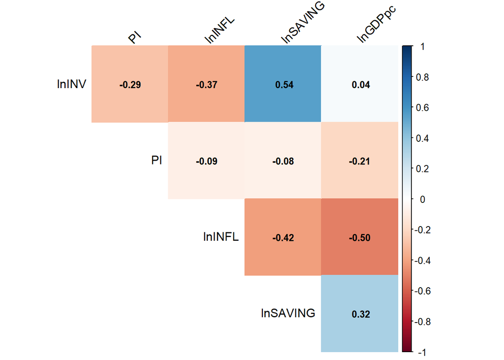

```r
# Correlation heatmap
corrplot(
  cor_mat,
  method      = "color",
  type        = "upper",
  addCoef.col = "black",
  tl.col      = "black",
  tl.srt      = 45,
  number.cex  = 0.8,
  diag        = FALSE                                      # hide diagonal
)
```

The correlation matrix shows a few clear patterns. First, investment ($\ln INV$) is moderately positively correlated with saving ($\ln SAVING$, 0.54) and negatively correlated with inflation ($\ln INFL$, $-0.37$), which is consistent with the idea that higher domestic saving supports investment while high inflation discourages it. The correlation between investment and political instability ($PI$) is negative and moderate ($-0.29$), in line with the expectation that greater instability is associated with lower investment. The correlation between investment and GDP per capita ($\ln GDPpc$) is close to zero (0.04). Among the regressors, correlations remain moderate: inflation is negatively related to both saving and income ($-0.42$ and $-0.50$), while saving and GDP per capita are only mildly positively correlated (0.32). Overall, these patterns are economically plausible and suggest no severe multicollinearity problem.

## 3.5. Estimation of the model

```r
inv_model <- lm(
  lnINV ~ PI + lnINFL + lnSAVING + lnGDPpc,
  data = data_model
)

summary(inv_model)
```

```
##
## Call:
## lm(formula = lnINV ~ PI + lnINFL + lnSAVING + lnGDPpc, data = data_model)
##
## Residuals:
##      Min       1Q   Median       3Q      Max
## -0.47522 -0.15403  0.00018  0.13305  0.36378
##
## Coefficients:
##             Estimate Std. Error t value Pr(>|t|)
## (Intercept)  3.25508    0.41282   7.885 5.36e-09 ***
## PI          -0.12372    0.04480  -2.762  0.00945 **
## lnINFL      -0.10357    0.04119  -2.514  0.01715 *
## lnSAVING     0.27711    0.08240   3.363  0.00201 **
## lnGDPpc     -0.09046    0.03554  -2.545  0.01595 *
## ---
## Signif. codes:  0 '***' 0.001 '**' 0.01 '*' 0.05 '.' 0.1 ' ' 1
##
## Residual standard error: 0.2225 on 32 degrees of freedom
## Multiple R-squared:  0.4938, Adjusted R-squared:  0.4305
## F-statistic: 7.804 on 4 and 32 DF,  p-value: 0.0001654
```

## 3.6. Specification and diagnostic tests

We now assess whether the main OLS assumptions are reasonably satisfied by performing a set of standard diagnostic tests on the residuals of the model (Breusch–Pagan for homoskedasticity, Breusch–Godfrey for serial correlation, Jarque–Bera and Shapiro–Wilk for normality, and RESET for functional form).

```r
# Run the main diagnostic tests
bptest(inv_model)                        # heteroskedasticity
```

```
##
##  studentized Breusch-Pagan test
##
## data:  inv_model
## BP = 3.6982, df = 4, p-value = 0.4484
```

```r
bgtest(inv_model)                        # autocorrelation
```

```
##
##  Breusch-Godfrey test for serial correlation of order up to 1
##
## data:  inv_model
## LM test = 2.633, df = 1, p-value = 0.1047
```

```r
jarque.bera.test(residuals(inv_model))   # normality (Jarque-Bera)
```

```
##
##  Jarque Bera Test
##
## data:  residuals(inv_model)
## X-squared = 0.59901, df = 2, p-value = 0.7412
```

```r
shapiro.test(residuals(inv_model))       # normality (Shapiro-Wilk)
```

```
##
##  Shapiro-Wilk normality test
##
## data:  residuals(inv_model)
## W = 0.97139, p-value = 0.4475
```

```r
resettest(inv_model)                     # functional form
```

```
##
##  RESET test
##
## data:  inv_model
## RESET = 0.1606, df1 = 2, df2 = 30, p-value = 0.8524
```

The diagnostic tests reported above all display p-values well above the 5% level. The Breusch–Pagan test does not reject the null of homoskedasticity, and the Breusch–Godfrey test does not indicate significant serial correlation. Both the Jarque–Bera and Shapiro–Wilk tests fail to reject the normality of the residuals, and the RESET test suggests that the log–linear specification is not misspecified. Overall, these results provide no evidence against the main OLS assumptions.

#### Multicollinearity - VIF

To check for potential multicollinearity among the regressors, we also compute the Variance Inflation Factors (VIFs) of the model.

```r
vif(inv_model)
```

```
##       PI   lnINFL lnSAVING  lnGDPpc
## 1.110335 1.578728 1.248850 1.476926
```

All VIF values are close to 1 and well below conventional thresholds such as 5 or 10, indicating that multicollinearity is not a serious concern in this specification. The explanatory variables are therefore sufficiently distinct to allow a meaningful interpretation of their individual coefficients.

Taken together, the diagnostic tests suggest that the model is reasonably well specified and statistically stable. In the next section, we can therefore interpret the estimated coefficients as robust partial correlations between political instability, macroeconomic conditions and investment.

## 4. Interpretation of the results

The estimated log-linear specification is the following:

All slope coefficients are statistically significant at the 5% level, and some at the 1% level. The model explains about half of the cross-country variation in the investment rate (R-squared ≈ 0.49; adjusted R-squared ≈ 0.43), and the overall F-test strongly rejects the null of no joint effect of the regressors $(p \approx 0.00017)$.

### Interpretation of the coefficients

- **Political instability index (PI)**  
  The coefficient on $\text{PI}_i$ is $\hat{\beta} = -0.124$ and is negative and statistically significant at the 1% level. Since $\text{PI}_i$ enters in level while the dependent variable is in logarithm, $\hat{\beta}$ can be interpreted as a **semi-elasticity**:  
  a one-point increase in political instability (higher $\text{PI}_i$) is associated with approximately **12.4% lower investment rate** (as a share of GDP), holding inflation, savings and GDP per capita constant.

The negative coefficient is therefore consistent with the idea that political instability discourages investment by increasing uncertainty and weakening the business environment.

- **Inflation (lnINFL)**  
  The estimated coefficient on $\ln(\text{INFL}_i)$ is $\hat{\gamma}_1 = -0.104$ and is statistically significant at the 5% level. Since both the dependent variable and this regressor are in logs, $\hat{\gamma}_1$ is an **elasticity**:  
  a 1% increase in the inflation rate is associated with roughly **0.10% lower investment rate**, ceteris paribus.  
  This negative sign is in line with the view that higher inflation reflects macroeconomic instability and increases uncertainty, which can discourage long-term investment.
- **Gross savings (lnSAVING)**  
  The coefficient on $\ln(\text{SAVING}_i)$ is $\hat{\gamma}_2 = 0.277$, significant at the 1% level. This implies that a 1% increase in the gross saving rate is associated with about **0.28% higher investment rate**, all else equal.  
  This positive elasticity reflects the fact that domestic savings provide resources to finance investment and that countries with higher saving ratios tend to allocate a larger share of their GDP to capital formation.
- **GDP per capita (lnGDPpc)**  
  The coefficient on $\ln(\text{GDPpc}_i)$ is $\hat{\gamma}_3 = -0.090$, significant at the 5% level. This suggests that a 1% increase in GDP per capita is associated with roughly **0.09% lower investment rate** (as a percentage of GDP), holding other factors constant.  
  Although the sign is negative, this is not necessarily counter-intuitive: since the dependent variable is an **investment share** (investment/GDP), poorer countries may need to devote a larger fraction of their output to capital accumulation in order to catch up, whereas richer economies can sustain growth with a lower investment share and a higher existing capital stock. This pattern is compatible with convergence-type arguments.

### Overall assessment

Taken together, the results show that:

- Political instability (higher $\text{PI}_i$) is negatively and significantly associated with the investment rate;
- Macroeconomic instability, proxied by inflation, is negatively related to investment;
- Domestic savings play a strong and positive role in supporting investment;
- Investment shares tend to be higher in relatively poorer countries (in terms of GDP per capita).

Under the assumption that the diagnostic tests reported in the previous section do not point to major violations of the OLS assumptions (in particular with respect to heteroskedasticity, normality and functional form), the estimated coefficients can be interpreted as robust partial correlations between political instability, macroeconomic conditions and investment in Africa and the Middle East in 2023.

# 5. Limitations of the model

This empirical exercise is subject to several important limitations.

- First, the analysis is based on a single cross-section (year 2023). As a result, the model cannot capture dynamic effects or control for unobserved country–specific factors (historical, institutional or cultural) that are constant over time but may affect both political instability and investment.
- Second, the OLS estimates are likely to suffer from endogeneity. Political instability may be influenced by economic performance: low investment and weak growth can fuel social unrest and institutional fragility. In addition, several relevant determinants of investment are omitted from the regression (human capital, financial development, trade openness, quality of infrastructure, etc.), so the coefficient on PI may partly reflect the effect of these missing variables.
- Third, the measurement of instability relies on a single composite index (PV.EST). This indicator is useful but imperfect: it may not fully capture all dimensions of political risk (conflict intensity, regime changes, quality of governance) and is subject to perception and measurement errors. Similarly, using national averages for inflation, savings and GDP per capita masks within-country heterogeneity.
- Fourth, the sample size is limited and countries with missing or non-positive values for key variables are dropped, which may introduce selection bias. Extreme values, especially for inflation, can also affect the estimates despite the log transformation.
- Finally, the specification is deliberately simple and linear, with constant elasticities and semi-elasticities. Non-linear relationships, threshold effects or interactions between political instability and macroeconomic variables are not explored here.

For all these reasons, the results should be interpreted as descriptive cross-country correlations rather than strict causal effects of political instability on investment.

# Thank you for taking the time to read this :)